# Data Analysis and Lab HW4

Na SeungChan

2023-12-13

# Problem 1.

```r
df <- read.csv("welder.csv")
head(df)
```

|  | welder | age | race | smoker | DPC |
| --- | --- | --- | --- | --- | --- |
| 1 | 1 | 38 | C | N | 1.77 |
| 2 | 1 | 44 | C | N | 1.02 |
| 3 | 1 | 39 | C | Y | 1.44 |
| 4 | 1 | 33 | AA | Y | 0.65 |
| 5 | 1 | 35 | C | Y | 2.08 |
| 6 | 1 | 39 | C | Y | 0.61 |

## (a)

Compare the covariate balance between treated group and control group. Find the mean of treated group, mean of control group, and standardized mean difference for each covariate. Discuss the result.

```r
no.adj <- matchit(welder ~ age + race + smoker, data = df, method = NULL, distance = "glm")
summary(no.adj)
```

```
##
## Call:
## matchit(formula = welder ~ age + race + smoker, data = df, method = NULL,
##     distance = "glm")
##
## Summary of Balance for All Data:
##          Means Treated Means Control Std. Mean Diff. Var. Ratio eCDF Mean
## distance        0.6437        0.2878          3.0780     0.1393    0.3144
## age            38.2381       42.6923         -0.8754     0.3725    0.1485
## raceAA          0.0952        0.1923         -0.3307          .    0.0971
## raceC           0.9048        0.3462          1.9030          .    0.5586
## raceCC          0.0000        0.4615         -1.2448          .    0.4615
## smokerN         0.4762        0.6538         -0.3557          .    0.1777
## smokerY         0.5238        0.3462          0.3557          .    0.1777
##          eCDF Max
## distance   0.5788
## age        0.3773
## raceAA     0.0971
## raceC      0.5586
## raceCC     0.4615
## smokerN    0.1777
## smokerY    0.1777
##
## Sample Sizes:
##           Control Treated
## All            26      21
## Matched        26      21
## Unmatched       0       0
## Discarded       0       0
```

```r
df %>%
  group_by(welder) %>%
  summarise(mean(DPC), sd(DPC))
```

| welder | mean(DPC) | sd(DPC) |
| --- | --- | --- |
| 0 | 1.171538 | 0.4641611 |
| 1 | 1.854286 | 1.1321818 |

Standardized Mean Difference for each covariate : 크게 차이나므로 이를 적절히 보정해야 한다.

## (b)

Estimate the propensity score via logistic regression. Plot the density of propensity score for treated and control groups. Discuss the result.

```r
ps.glm <- glm(welder ~ age + race + smoker, data = df, family=binomial, x=T)
summary(ps.glm)
```

```
##
## Call:
## glm(formula = welder ~ age + race + smoker, family = binomial,
##     data = df, x = T)
##
## Coefficients:
##               Estimate Std. Error z value Pr(>|z|)
## (Intercept)    0.20961    2.94727   0.071    0.943
## age           -0.02818    0.06395  -0.441    0.659
## raceC          1.54733    0.97837   1.582    0.114
## raceCC       -17.54235 1872.33444  -0.009    0.993
## smokerY        0.13687    0.74676   0.183    0.855
##
## (Dispersion parameter for binomial family taken to be 1)
##
##     Null deviance: 64.623  on 46  degrees of freedom
## Residual deviance: 43.276  on 42  degrees of freedom
## AIC: 53.276
##
## Number of Fisher Scoring iterations: 17
```

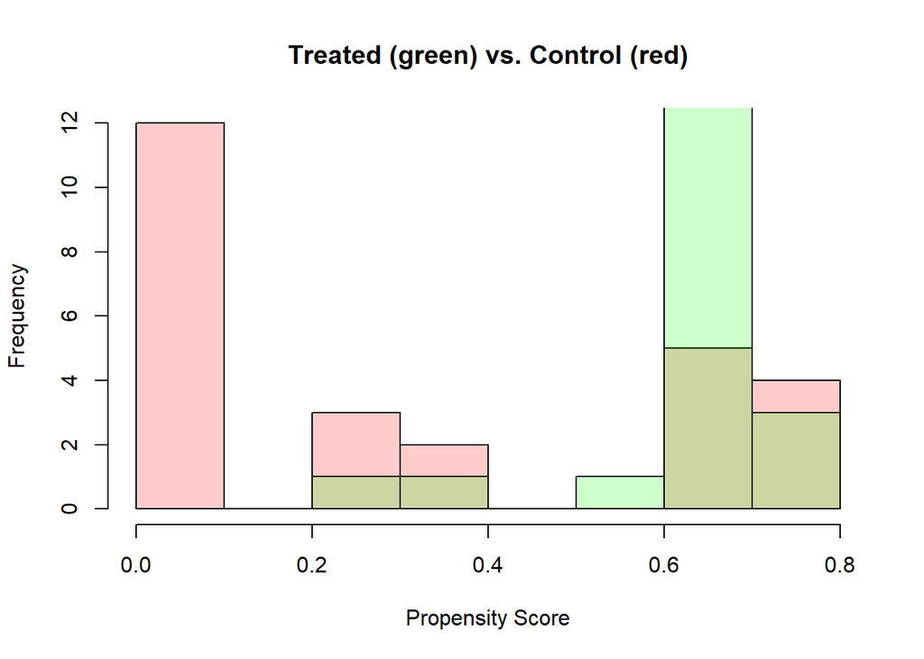

```r
estimates_ps <- ps.glm$fitted.values
# 1/(1+exp((-1)*(model.matrix(ps.glm)[,-1]%*%ps.glm$coefficients[c(2:5)])))

hist(estimates_ps[df$welder==0], col = rgb(1, 0, 0, 0.2), xlab = "Propensity Score", main = "Treated (green) vs. Control (red)")
hist(estimates_ps[df$welder==1], col = rgb(0, 1, 0, 0.2), add = T)
```

## (c)

Implement 1:1 Propensity Score Matching with replacement (use the propensity score estimated by logistic regression). Discuss the covariate balance (standardized mean difference) after matching.

```r
ps.mat11_7 <- matchit(welder ~ age + race + smoker, data = df, method = 'nearest', distance = estimates_ps, replace = T)
summary(ps.mat11_7, un = F)
```

```
##
## Call:
## matchit(formula = welder ~ age + race + smoker, data = df, method = "nearest",
##     distance = estimates_ps, replace = T)
##
## Summary of Balance for Matched Data:
##          Means Treated Means Control Std. Mean Diff. Var. Ratio eCDF Mean
## distance        0.6437        0.6481         -0.0377     0.7685    0.0347
## age            38.2381       37.6190          0.1217     1.2294    0.0556
## raceAA          0.0952        0.0952          0.0000          .    0.0000
## raceC           0.9048        0.9048          0.0000          .    0.0000
## raceCC          0.0000        0.0000          0.0000          .    0.0000
## smokerN         0.4762        0.4762          0.0000          .    0.0000
## smokerY         0.5238        0.5238          0.0000          .    0.0000
##          eCDF Max Std. Pair Dist.
## distance   0.2857          0.0803
## age        0.2381          0.4773
## raceAA     0.0000          0.0000
## raceC      0.0000          0.0000
## raceCC     0.0000          0.0000
## smokerN    0.0000          0.1905
## smokerY    0.0000          0.1905
##
## Sample Sizes:
##               Control Treated
## All             26.        21
## Matched (ESS)    4.12      21
## Matched          8.        21
## Unmatched       18.         0
## Discarded        0.         0
```

```r
ps.mat11_7$match.matrix
```

```
##    [,1]
## 1  "41"
## 2  "40"
## 3  "43"
## 4  "36"
## 5  "47"
## 6  "43"
## 7  "42"
## 8  "41"
## 9  "43"
## 10 "22"
## 11 "41"
## 12 "41"
## 13 "41"
## 14 "41"
## 15 "43"
## 16 "43"
## 17 "47"
## 18 "44"
## 19 "43"
## 20 "41"
## 21 "43"
```

matching 후, 모든 Std. Mean Diff의 최댓값이 0.1보다 약간 큰 수준으로acceptable하다. 이와 같이 group 간 차이가 보정되어 각 group의 차이가 없는 것으로 생각하고 각 group의 DPC value 차이를 treatment가 random assignment된 것에 따라 발생한 인과관계에서 발생하는 ATT로 생각할 수 있게 된다.

참고로, 아래의 결과를 확인하면 `replace = T` option이 얼마나 큰 차이를 만들었는지 알 수 있다. 41이 얼마나 많이 반복되는지! sample 수가 아무리 작아도 이렇게 하는 게 현실 연구에서도 맞는지는 모르겠다…

## (d)

Using the matched set in (c), find the estimate and 95% confidence interval of the average treatment effect on treated (ATT).

```r
mat117_data <- match.data(ps.mat11_7)
fit_DPC_treat <- lm(DPC ~ welder, data = mat117_data, weights = weights)
avg_comparisons(fit_DPC_treat, variables = "welder", vcov = 'HC3', newdata = subset(mat117_data, welder == 1), wts = "weights")
```

| term | contrast | estimate | std.error | statistic | p.value | s.value | conf.low | conf.high |
| --- | --- | --- | --- | --- | --- | --- | --- | --- |
| welder | 1 - 0 | 0.4885714 | 0.6627697 | 0.7371662 | 0.4610213 | 1.117095 | -0.8104334 | 1.787576 |

## (e)

Construct a propensity score stratification with 3 strata (use the propensity score estimated by logistic regression). Discuss the covariate balance across subclasses.

```r
ps.mat11_3 <- matchit(welder ~ age + race + smoker, data = df, methods = 'nearest', distance = estimates_ps, subclass = 3)
summary(ps.mat11_3, un = F)
```

```
##
## Call:
## matchit(formula = welder ~ age + race + smoker, data = df, distance = estimates_ps,
##     methods = "nearest", subclass = 3)
##
## Summary of Balance for Matched Data:
##          Means Treated Means Control Std. Mean Diff. Var. Ratio eCDF Mean
## distance        0.6437        0.3563          2.4855     0.1418    0.2329
## age            38.2381       40.0952         -0.3650     0.6108    0.0774
## raceAA          0.0952        0.2381         -0.4867          .    0.1429
## raceC           0.9048        0.4286          1.6222          .    0.4762
## raceCC          0.0000        0.3333         -0.8990          .    0.3333
## smokerN         0.4762        0.5714         -0.1907          .    0.0952
## smokerY         0.5238        0.4286          0.1907          .    0.0952
##          eCDF Max Std. Pair Dist.
## distance   0.5238          2.5002
## age        0.2857          1.1137
## raceAA     0.1429          1.1355
## raceC      0.4762          1.6222
## raceCC     0.3333          0.8990
## smokerN    0.0952          1.3348
## smokerY    0.0952          1.3348
##
## Sample Sizes:
##           Control Treated
## All            26      21
## Matched        21      21
## Unmatched       5       0
## Discarded       0       0
```

```r
mat113_data <- match.data(ps.mat11_3)
fit_DPC_treat2 <- lm(DPC ~ welder, data = mat113_data, weights = weights)
avg_comparisons(fit_DPC_treat2, variables = "welder", vcov = 'HC3', newdata = subset(mat113_data, welder == 1), wts = "weights")
```

| term | contrast | estimate | std.error | statistic | p.value | s.value | conf.low | conf.high |
| --- | --- | --- | --- | --- | --- | --- | --- | --- |
| welder | 1 - 0 | 0.7042857 | 0.2731754 | 2.578145 | 0.009933232 | 6.653521 | 0.1688718 | 1.2397 |

replace = FALSE로 설정한 결과 standardized mean diff가 매우 크다. 이걸 쓰는 게 적절하지 않아 보인다.

## (f)

Using the strata in (e), find the estimate and 95% confidence interval of the average treatment effect (ATE).

```r
ps.mat12_3 <- matchit(welder ~ age + race + smoker, data = df, methods = 'nearest', distance = 'glm', link = 'probit', subclass = 3, replace = T)
summary(ps.mat12_3, un = F)
```

```
##
## Call:
## matchit(formula = welder ~ age + race + smoker, data = df, distance = "glm",
##     link = "probit", replace = T, methods = "nearest", subclass = 3)
##
## Summary of Balance for Matched Data:
##          Means Treated Means Control Std. Mean Diff. Var. Ratio eCDF Mean
## distance        0.6431        0.6453         -0.0194     0.7979    0.0296
## age            38.2381       37.9524          0.0562     1.2366    0.0456
## raceAA          0.0952        0.0952          0.0000          .    0.0000
## raceC           0.9048        0.9048          0.0000          .    0.0000
## raceCC          0.0000        0.0000          0.0000          .    0.0000
## smokerN         0.4762        0.4762          0.0000          .    0.0000
## smokerY         0.5238        0.5238          0.0000          .    0.0000
##          eCDF Max Std. Pair Dist.
## distance   0.2381          0.0876
## age        0.1905          0.4118
## raceAA     0.0000          0.0000
## raceC      0.0000          0.0000
## raceCC     0.0000          0.0000
## smokerN    0.0000          0.1905
## smokerY    0.0000          0.1905
##
## Sample Sizes:
##               Control Treated
## All             26.        21
## Matched (ESS)    4.64      21
## Matched          9.        21
## Unmatched       17.         0
## Discarded        0.         0
```

```r
mat123_data <- match.data(ps.mat12_3)
fit_DPC_treat3 <- lm(DPC ~ welder, data = mat123_data, weights = weights)
avg_comparisons(fit_DPC_treat3, variables = "welder", newdata = subset(mat123_data, welder == 1), wts = "weights")
```

| term | contrast | estimate | std.error | statistic | p.value | s.value | conf.low | conf.high |
| --- | --- | --- | --- | --- | --- | --- | --- | --- |
| welder | 1 - 0 | 0.5147619 | 0.4147449 | 1.241153 | 0.2145492 | 2.220619 | -0.2981232 | 1.327647 |

(-0.298, 1.33), 0.515.

estimand option ’ATE’가 몇몇 option에 대해 가능하지만… 다음과 같은 오류를 출력한다.

```r
ps.mat12_3 <- matchit(welder ~ age + race + smoker, data = df, methods = 'nearest', distance = 'glm', link = 'probit', estimand = 'ATE', subclass = 3, replace = T)
```

```
## Error in `matchit()`:
## ! The argument to `estimand` should be one of "ATT" or "ATC".
```

```r
summary(ps.mat12_3, un = F)
```

```
##
## Call:
## matchit(formula = welder ~ age + race + smoker, data = df, distance = "glm",
##     link = "probit", replace = T, methods = "nearest", subclass = 3)
##
## Summary of Balance for Matched Data:
##          Means Treated Means Control Std. Mean Diff. Var. Ratio eCDF Mean
## distance        0.6431        0.6453         -0.0194     0.7979    0.0296
## age            38.2381       37.9524          0.0562     1.2366    0.0456
## raceAA          0.0952        0.0952          0.0000          .    0.0000
## raceC           0.9048        0.9048          0.0000          .    0.0000
## raceCC          0.0000        0.0000          0.0000          .    0.0000
## smokerN         0.4762        0.4762          0.0000          .    0.0000
## smokerY         0.5238        0.5238          0.0000          .    0.0000
##          eCDF Max Std. Pair Dist.
## distance   0.2381          0.0876
## age        0.1905          0.4118
## raceAA     0.0000          0.0000
## raceC      0.0000          0.0000
## raceCC     0.0000          0.0000
## smokerN    0.0000          0.1905
## smokerY    0.0000          0.1905
##
## Sample Sizes:
##               Control Treated
## All             26.        21
## Matched (ESS)    4.64      21
## Matched          9.        21
## Unmatched       17.         0
## Discarded        0.         0
```

```r
mat123_data <- match.data(ps.mat12_3)
fit_DPC_treat3 <- lm(DPC ~ welder, data = mat123_data, weights = weights)
avg_comparisons(fit_DPC_treat3, variables = "welder", newdata = subset(mat123_data, welder == 1), wts = "weights")
```

| term | contrast | estimate | std.error | statistic | p.value | s.value | conf.low | conf.high |
| --- | --- | --- | --- | --- | --- | --- | --- | --- |
| welder | 1 - 0 | 0.5147619 | 0.4147449 | 1.241153 | 0.2145492 | 2.220619 | -0.2981232 | 1.327647 |

## (g)

Find the estimate and 95% confidence interval of the average treatment effect (ATE) using inverse probability weighting (IPW, use the propensity score estimated by logistic regression).

```r
Wmodel <- weightit(welder ~ age + race + smoker, data = df, methods = 'nearest', estimand = 'ATE', distance = estimates_ps)
bal.tab(Wmodel, un = T)
```

```
## Balance Measures
##                Type Diff.Un Diff.Adj
## prop.score Distance  1.5223   0.6690
## age         Contin. -0.6450  -0.2678
## race_AA      Binary -0.0971   0.0417
## race_C       Binary  0.5586   0.2119
## race_CC      Binary -0.4615  -0.2536
## smoker_Y     Binary  0.1777   0.0769
##
## Effective sample sizes
##            Control Treated
## Unadjusted   26.     21.
## Adjusted     19.94   18.91
```

```r
W_data <- df
W_data$ipw.weights <- Wmodel$weights
fit_Wtreat <- lm(DPC ~ welder, data = W_data, weights = ipw.weights)
avg_comparisons(fit_Wtreat, variables = "welder", vcov = 'HC3', newdata = subset(W_data, welder == 1), wts = 'ipw.weights')
```

| term | contrast | estimate | std.error | statistic | p.value | s.value | conf.low | conf.high |
| --- | --- | --- | --- | --- | --- | --- | --- | --- |
| welder | 1 - 0 | 0.5915602 | 0.282743 | 2.092219 | 0.03641896 | 4.779166 | 0.03739408 | 1.145726 |

(0.0374, 1.15), 0.592

## (h)

Compare three estimates in (d), (f), (g). Choose the estimate that you consider the best and discuss the reason.